# More Missing Data

Lecture 34

April 22, 2026

# Review

## Missing Data Notation

Let $M_Y$ be the indicator function for whether $Y$ is missing and let $\pi(x) = \mathbb{P}(M_Y = 0 | X = x)$ be the **inclusion** probability.

**Goal**: Understand the **complete-data** distribution $\mathbb{P}(Y=y | X=x)$.

But we only have the **observed** distribution $\mathbb{P}(Y = y | X=x, M_Y = 0) \pi(x)$. We are missing $\mathbb{P}(Y = y | X=x, M_Y = 1) (1-\pi(x))$.

## Missingness Complete At Random (MCAR)

**MCAR**: $M_Y$ is independent of $X=x$ and $Y=y$.

Complete cases are fully representative of the complete data:

$$\mathbb{P}(Y=y) = P(Y=y | M_Y=0)$$

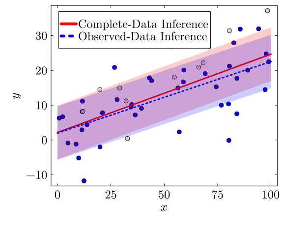

Figure 1: Illustration of MCAR Data

```julia
n = 50
x = rand(Uniform(0, 100), n)
logit(x) = log(x / (1 - x))
invlogit(x) = exp(x) / (1 + exp(x))
f(x) = invlogit(0.05 * (x - 50) + rand(Normal(0, 1)))

flin(x) = 0.25 * x + 2 + rand(Normal(0, 7))
y = flin.(x)
xpred = collect(0:0.1:100)

lm_all = lm([ones(length(x)) x], y)
y_lm_all = predict(lm_all, [ones(length(xpred)) xpred])

missing_y = Bool.(rand(Binomial.(1, 0.25), length(y)))
xobs = x[.!(missing_y)]
yobs = y[.!(missing_y)]
lm_mcar = lm([ones(n - sum(missing_y)) xobs], yobs)
y_lm_mcar = predict(lm_mcar, [ones(length(xpred)) xpred])


p1 = scatter(xobs, yobs, xlabel=L"$x$", ylabel=L"$y$", label=false, markersize=5, size=(600, 500), color=:blue)
scatter!(x[missing_y], y[missing_y], alpha=0.9, color=:lightgrey, label=false, markersize=5)
plot!(xpred, y_lm_all, color=:red, lw=3, label="Complete-Data Inference", ribbon=GLM.dispersion(lm_all), fillalpha=0.2)
plot!(xpred, y_lm_mcar, color=:blue, lw=3, linestyle=:dot, label="Observed-Data Inference", ribbon=GLM.dispersion(lm_mcar), fillalpha=0.2)
```

## Missingness At Random (MAR)

**MAR**: $M_Y$ is independent of $Y=y$ **conditional on $X=x$**.

Also called **ignorable** or **uninformative missingness**.

$$\begin{align*}
\mathbb{P}&(Y=y | X=x) \\
&= \mathbb{P}(Y=y | X=x, M_Y=0)
\end{align*}$$

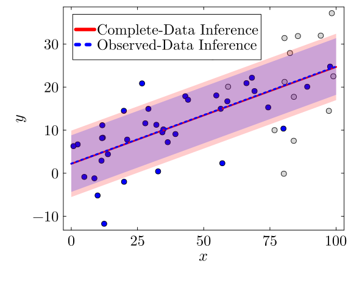

Figure 2: Illustration of MAR Data

```julia
missing_y = Bool.(rand.(Binomial.(1,  invlogit.(0.1 * (x .- 75)))))
xobs = x[.!(missing_y)]
yobs = y[.!(missing_y)]
lm_mar = lm([ones(n - sum(missing_y)) xobs], yobs)
y_lm_mar = predict(lm_mar, [ones(length(xpred)) xpred])

p2 = scatter(xobs, yobs, xlabel=L"$x$", ylabel=L"$y$", label=false, markersize=5, size=(600, 500), color=:blue)
scatter!(x[missing_y], y[missing_y], alpha=0.9, color=:lightgrey, label=false, markersize=5)
plot!(xpred, y_lm_all, color=:red, lw=3, label="Complete-Data Inference", ribbon=GLM.dispersion(lm_all), fillalpha=0.2)
plot!(xpred, y_lm_mar, color=:blue, lw=3, linestyle=:dot, label="Observed-Data Inference", ribbon=GLM.dispersion(lm_mar), fillalpha=0.2)
```

## Missingness Not-At-Random (MNAR)

**MNAR**: $M_Y$ is dependent on $Y=y$ (and/or unmodeled variables).

Also called **non-ignorable** or **informative missingness**.

$$\begin{align*}
\mathbb{P}&(Y=y | X=x) \\
&\neq \mathbb{P}(Y=y | X=x, M_Y=0)
\end{align*}$$

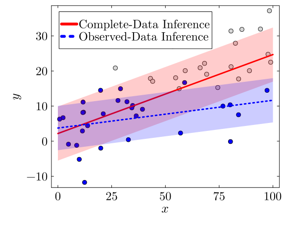

```julia
missing_y = Bool.(rand.(Binomial.(1,  invlogit.(0.9 * (y .- 15)))))
xobs = x[.!(missing_y)]
yobs = y[.!(missing_y)]
lm_mnar = lm([ones(n - sum(missing_y)) xobs], yobs)
y_lm_mnar = predict(lm_mnar, [ones(length(xpred)) xpred])

p2 = scatter(xobs, yobs, xlabel=L"$x$", ylabel=L"$y$", label=false, markersize=5, size=(600, 500), color=:blue)
scatter!(x[missing_y], y[missing_y], alpha=0.9, color=:lightgrey, label=false, markersize=5)
plot!(xpred, y_lm_all, color=:red, lw=3, label="Complete-Data Inference", ribbon=GLM.dispersion(lm_all), fillalpha=0.2)
plot!(xpred, y_lm_mnar, color=:blue, lw=3, linestyle=:dot, label="Observed-Data Inference", ribbon=GLM.dispersion(lm_mnar), fillalpha=0.2)
```

## Implications of Missingness Mechanism

# Checking Assumptions About Missingness

## Checking MCAR

In general, we can’t know for sure if missingness $M_Y$ is informative about $Y$ (since we can’t see it!).

But we can check if $M_Y$ is independent of $X$: if not, reject MCAR.

**Can we conclude MCAR if, in our dataset, $M_Y$ appears independent of $X$?**

## Distinguishing MAR from MNAR

Can’t do this statistically!

MAR: $\mathbb{P}(Y=y | X-x, M_Y=1) = \mathbb{P}(Y=y | X-x, M_Y=0)$

But the data tells us nothing about $\mathbb{P}(Y=y | X-x, M_Y=1)$. Need to bring to bear understanding of data-collection process.

Instead, try a few different models reflecting different assumptions about missingness: do your conclusions change?

# Methods for Dealing with Missing Data

## Methods for Dealing with Missing Data

1. **Imputation**: substitute values for missing data before analysis;
2. **Averaging**: find expected values over all possible values of the missing variables.

## Imputation

Imputation does not create “new” information, it reuses existing information to allow the use of standard procedures.

**Example**: Missing observations in a time series, want to insert values to fit AR(1) model or estimate autocorrelation using “simple” estimators.

As a result, it’s convenient but can create systematic distortions.

- Impute from the marginal distribution (parametrically or non-parametrically),
  $$p(Y_\text{miss}) = p(Y_\text{obs}).$$
  This can create distortions if meaningful relationships are neglected.
- Impute using a regression model (such as linear imputation). This generalizes relationships but requires missingness being uninformative about $Y$.

## Imputation Under MAR

- Impute from the conditional distribution,
  $$p(Y_\text{miss} | X = x) = p(Y_\text{obs} | X = x).$$
  Can be done parametrically or non-parametrically.
- Impute using **matching**: find a closest predictor and copy value of $Y$. Can work okay or be a terrible idea.

## Imputation Under MNAR

Need to model missingness mechanism (censoring, etc).

Often need to make assumptions about how the relationship extrapolates.

- Model relationship between predictors and missing data;
- Add unknown constant to imputed data to reflect biases.

**Ultimately, MNAR requires a sensitivity analysis**.

# Key Points and Upcoming Schedule

## Key Points

- Best approach to missing data is to not have any.
- Otherwise, try multiple imputation based on understanding/theories of missing mechanisms. Use as much data as possible in these models.
- Use as much information as possible when conducting multiple imputation.
- Incorporate as much uncertainty as possible to avoid biasing downstream results: we don’t know what the missing data looks like!

## Upcoming Schedule

**Friday**: Finish Missing Data. Class in 205 Riley-Robb

**Next Week**: Complete Poll on Ed.

## Assessments

**HW6** released, due 5/1.

**Quiz 4**: Due 5/1